# Downstream RNA-seq Analysis

From Count Matrix to Biological Insight | iPSC to Motor Neuron Differentiation

Shirley Li, xue.li37@tufts.edu

2026-06-10

# 1 Introduction

## 1.1 Overview of the RNA-seq workflow

RNA sequencing (RNA-seq) measures the expression level of every gene in a sample simultaneously. The full workflow has two major parts:

**Part 1 — Upstream (Session 1, run on Tufts HPC):** Raw sequencing reads (FASTQ files) → quality control → alignment to genome → quantification → **count matrix**

**Part 2 — Downstream (this tutorial, run in R):** Count matrix → normalization → quality control → differential expression → visualization → biological interpretation

This tutorial covers Part 2. By the end, you will have gone from a table of numbers to a list of biologically meaningful genes and pathways.

## 1.2 What is a count matrix?

After Session 1, nf-core/rnaseq produced a file called `salmon.merged.gene_counts.tsv`. This is the **count matrix** — a spreadsheet where:

- Each **row** is a gene (e.g., `ISL1`, `SOX2`, `HOXC9`)
- Each **column** is a sample (e.g., `D0_REP1`, `D13_REP2`, …)
- Each **cell** is the number of RNA-seq reads that mapped to that gene in that sample

A higher count means more RNA was present, which means the gene was more actively expressed. Our job is to find which genes change between conditions.

## 1.3 About the dataset

We are using a publicly available dataset from:

> Solomon E, Davis-Anderson K, Hovde B, Micheva-Viteva S, Harris JF, Twary S, Iyer R. (2021). **Global transcriptome profile of the developmental principles of in vitro iPSC-to-motor neuron differentiation.** *BMC Molecular and Cell Biology*, 22(1):13.
- **NCBI BioProject:** PRJNA638768
- **Experiment:** Human iPSCs (WTC-11 cell line) were differentiated into spinal motor neurons over 28 days, sampled at 3 timepoints
- **Design:** 3 biological replicates × 3 timepoints = **9 samples total**

> **Note:** The original published dataset includes 5 timepoints (D0, D7, D13, D18, D28; 15 samples total). For this hands-on tutorial we use a simplified 3-timepoint subset — D0, D13, and D28 — to keep computation time short and the comparisons easy to follow. All the analytical steps are identical; you can apply them directly to the full 5-timepoint dataset.

| Day | Cell Type | Abbreviation | What it represents |
| --- | --- | --- | --- |
| D0 | Induced pluripotent stem cell | iPSC | Starting pluripotent state |
| D13 | Motor neuron progenitor | MNP | Progenitors of motor neurons |
| D28 | Mature motor neuron | mMN | Fully differentiated motor neurons |

This is a **differentiation time-course** experiment. We will track how gene expression changes at each step of the journey from stem cell to motor neuron.

## 1.4 Biological motivation

Motor neurons — the cells that connect the spinal cord to muscles — are selectively lost in ALS and spinal muscular atrophy (SMA). Human iPSCs provide a powerful way to generate these cells in the lab, enabling researchers to study disease mechanisms and understand the transcriptional programs that drive motor neuron identity. This tutorial walks through the RNA-seq analysis of one such differentiation experiment.

## 1.5 R packages used in this tutorial

| Package | What it does | Why we need it |
| --- | --- | --- |
| `DESeq2` | Differential expression analysis | The gold standard tool for finding DEGs from count data |
| `ggplot2` | Data visualization | Flexible, publication-quality plotting |
| `pheatmap` | Heatmaps | Visualize expression patterns across many genes |
| `EnhancedVolcano` | Volcano plots | Highlight significant genes at a glance |
| `clusterProfiler` | GO and KEGG enrichment | Link gene lists to biological processes |
| `org.Hs.eg.db` | Human gene annotation | Convert gene IDs for enrichment analysis |
| `dplyr` / `tidyr` | Data wrangling | Clean, filter, and reshape data frames |
| `RColorBrewer` | Color palettes | Accessible, consistent color schemes |
| `ggrepel` | Non-overlapping labels | Label genes on plots without clutter |

# 2 Setup

## 2.1 Install packages

You only need to install packages once. After that, you just load them at the start of each session. Run this block once, then move on.

```r
# Install the Bioconductor package manager
if (!requireNamespace("BiocManager", quietly = TRUE))
  install.packages("BiocManager")

# Install Bioconductor packages (genomics-specific tools)
BiocManager::install(c(
  "DESeq2",           # differential expression
  "clusterProfiler",  # enrichment analysis
  "org.Hs.eg.db",     # human gene annotation database
  "EnhancedVolcano",  # volcano plots
  "AnnotationDbi"     # gene ID conversion utilities
))

# Install general R packages from CRAN
install.packages(c(
  "ggplot2",      # plotting
  "pheatmap",     # heatmaps
  "dplyr",        # data wrangling
  "tidyr",        # data reshaping
  "tibble",       # modern data frames
  "RColorBrewer", # color palettes
  "ggrepel",      # non-overlapping text labels on plots
  "ashr"          # LFC shrinkage method (required by lfcShrink)
))
```

## 2.2 Load packages

Every time you open a new R session, you need to load the packages you want to use. Think of installation as buying a book once, and loading as opening it from your shelf each time you need it.

```r
library(rlang)
library(DESeq2)
library(ggplot2)
library(pheatmap)
library(EnhancedVolcano)
library(clusterProfiler)
library(org.Hs.eg.db)
library(dplyr)
library(tidyr)
library(tibble)
library(RColorBrewer)
library(ggrepel)
library(ashr)
```

# 3 Configuration

## 3.1 File paths and analysis parameters

**Edit this block before running anything else.** Set `work_dir` to the root of your project folder on the HPC. All other paths are derived from it automatically.

```r
# ── EDIT THIS PATH ────────────────────────────────────────────────────────────
work_dir <- "/cluster/tufts/workshop/public/2026summer/iyerlab/part2"
# ─────────────────────────────────────────────────────────────────────────────

# Input file (derived from work_dir — no need to edit)
counts_file <- file.path(work_dir, "data/rnaseq/star_salmon/salmon.merged.gene_counts.tsv")

# Output directory — all result files (CSVs, etc.) will be saved here
out_dir <- file.path(work_dir, "results")
dir.create(out_dir, showWarnings = FALSE, recursive = TRUE)

cat("Configuration loaded.\n")
```

```
## Configuration loaded.
```

```r
cat("  Input counts:  ", counts_file, "\n")
```

```
##   Input counts:   /cluster/tufts/workshop/public/2026summer/iyerlab/part2/data/rnaseq/star_salmon/salmon.merged.gene_counts.tsv
```

```r
cat("  Output folder: ", out_dir, "\n")
```

```
##   Output folder:  /cluster/tufts/workshop/public/2026summer/iyerlab/part2/results
```

# 4 Load Data

## 4.1 Load the count matrix

The count matrix from nf-core comes as a tab-separated file. The first column contains Ensembl gene IDs, the second contains gene symbols, and the remaining columns are your 9 samples (named by timepoint and replicate, e.g., `D0_REP1`, `D13_REP2`).

Salmon quantification can produce fractional counts (e.g., 102.37). DESeq2 requires whole numbers, so we round to integers.

```r
# Read the count matrix
counts_raw <- read.table(
  counts_file,
  header = TRUE,
  sep    = "\t"
)

# Use gene_name (column 2) as row names — these are the HGNC gene symbols
# make.unique handles the rare case of duplicate gene names
rownames(counts_raw) <- make.unique(counts_raw$gene_name)

# Drop annotation columns; keep only the numeric count columns
counts_raw$gene_id   <- NULL
counts_raw$gene_name <- NULL

# Round fractional Salmon counts to integers (required by DESeq2)
counts <- round(counts_raw)

# Sanity check: expect ~78,000 genes and 9 samples
cat("Count matrix dimensions:\n")
```

```
## Count matrix dimensions:
```

```r
cat("  Genes:   ", nrow(counts), "\n")
```

```
##   Genes:    78899
```

```r
cat("  Samples: ", ncol(counts), "\n\n")
```

```
##   Samples:  9
```

```r
# Preview the top-left corner
counts[1:5, 1:3]
```

|  | D0_REP1 | D0_REP2 | D0_REP3 |
| --- | --- | --- | --- |
| TSPAN6 | 28 | 245 | 153 |
| TNMD | 0 | 3 | 1 |
| DPM1 | 61 | 421 | 378 |
| SCYL3 | 6 | 64 | 34 |
| FIRRM | 30 | 127 | 110 |

**What you should see:** A matrix of non-negative integers. Many genes will have zeros or very low counts — this is completely normal. Most genes are not expressed in any given cell type.

## 4.2 Build sample metadata

Rather than loading a separate file, we derive the metadata directly from the count matrix column names. Each column name encodes both the timepoint (`D0`, `D13`, `D28`) and the replicate number (`REP1`, `REP2`, `REP3`).

```r
# Parse day and replicate from column names (e.g., "D13_REP2" → day="D13", rep="REP2")
metadata <- data.frame(
  sample    = colnames(counts),
  day       = sub("_REP[0-9]+$", "", colnames(counts)),
  replicate = sub("^[^_]+_", "", colnames(counts)),
  row.names = colnames(counts),
  stringsAsFactors = FALSE
)

# Map timepoint to cell type
ct_map <- c("D0" = "iPSC", "D13" = "MNP", "D28" = "mMN")
metadata$cell_type <- ct_map[metadata$day]

# Set factor levels explicitly so all plots follow biological order
# (D0 → D13 → D28), not alphabetical order
metadata$day <- factor(
  metadata$day,
  levels = c("D0", "D13", "D28")
)
metadata$cell_type <- factor(
  metadata$cell_type,
  levels = c("iPSC", "MNP", "mMN")
)
metadata$replicate <- factor(metadata$replicate)

cat("Metadata:\n")
```

```
## Metadata:
```

```r
print(metadata)
```

```
##            sample day replicate cell_type
## D0_REP1   D0_REP1  D0      REP1      iPSC
## D0_REP2   D0_REP2  D0      REP2      iPSC
## D0_REP3   D0_REP3  D0      REP3      iPSC
## D13_REP1 D13_REP1 D13      REP1       MNP
## D13_REP2 D13_REP2 D13      REP2       MNP
## D13_REP3 D13_REP3 D13      REP3       MNP
## D28_REP1 D28_REP1 D28      REP1       mMN
## D28_REP2 D28_REP2 D28      REP2       mMN
## D28_REP3 D28_REP3 D28      REP3       mMN
```

# 5 Create the DESeq2 Object

All downstream analysis in DESeq2 works through a special R object called a `DESeqDataSet` (dds). It bundles together the count matrix, metadata, and the statistical design into one object.

## 5.1 What is a design formula?

The `design = ~ day` formula tells DESeq2 what variable to use for comparisons. `day` refers to the `day` column in our metadata — we want to compare gene expression between different differentiation days.

If your experiment had an additional variable (e.g., a batch effect), you could write `design = ~ batch + day`. For now, we keep it simple.

## 5.2 Setting the reference level

DESeq2 compares against a **reference level** — the baseline group. We set Day 0 (iPSC) as the reference because every timepoint will be compared back to the starting iPSC state.

```r
# Confirm column order matches between count matrix and metadata
stopifnot(all(rownames(metadata) == colnames(counts)))

# Build the DESeqDataSet
dds <- DESeqDataSetFromMatrix(
  countData = counts,
  colData   = metadata,
  design    = ~ day
)

# Set Day 0 (iPSC) as the reference — all comparisons will be vs. D0
dds$day <- relevel(dds$day, ref = "D0")

cat("DESeq2 object created.\n")
```

```
## DESeq2 object created.
```

```r
cat("Genes:", nrow(dds), "| Samples:", ncol(dds), "\n")
```

```
## Genes: 78899 | Samples: 9
```

## 5.3 Filter lowly expressed genes

Most of the ~30,000 genes in the human genome are not expressed in a given experiment. Keeping them wastes computation time and makes multiple-testing correction harsher (more tests = harder to find anything significant).

We remove genes where the **total count across all 9 samples is below 10**. If a gene has fewer than 10 reads in total, we cannot say anything meaningful about it. In this dataset, filtering reduces the gene set from 78,899 to 23,026 — about 71% of entries are too lowly expressed to test.

```r
# Keep genes with at least 10 total reads across all 9 samples
keep <- rowSums(counts(dds)) >= 10
dds  <- dds[keep, ]

cat("Genes before filtering:", sum(!keep) + nrow(dds), "\n")
```

```
## Genes before filtering: 78899
```

```r
cat("Genes after filtering:  ", nrow(dds), "\n")
```

```
## Genes after filtering:   23026
```

```r
cat("Genes removed:          ", sum(!keep), "\n")
```

```
## Genes removed:           55873
```

# 6 Quality Control

Before any statistical analysis, we must confirm the data looks as expected. QC catches problems like:

- A failed library (one sample with far fewer reads than others)
- A mislabeled sample (an iPSC clustering with mature motor neurons)
- A batch effect (samples processed on different days clustering apart)

**Rule of thumb:** Fix QC problems before running DESeq2. It is better to remove a bad sample than to let it distort your results.

## 6.1 VST normalization

Raw counts are not directly comparable between samples because sequencing depth varies — a sample with 50 million reads will have roughly twice the counts of a 25-million-read sample for the same gene.

We use **Variance Stabilizing Transformation (VST)** to:

1. Normalize for sequencing depth (makes samples comparable)
2. Stabilize variance (prevents highly expressed genes from dominating clustering and PCA)

**Important:** VST is for visualization and QC only. DESeq2 uses raw counts internally for the statistical model.

```r
# blind = TRUE: VST ignores the experimental design — gives unbiased QC
vsd <- vst(dds, blind = TRUE)
cat("VST normalization complete.\n")
```

```
## VST normalization complete.
```

## 6.2 Library sizes

The total number of reads per sample (library size) should be similar across samples. A sample with a very low library size may have a failed library preparation.

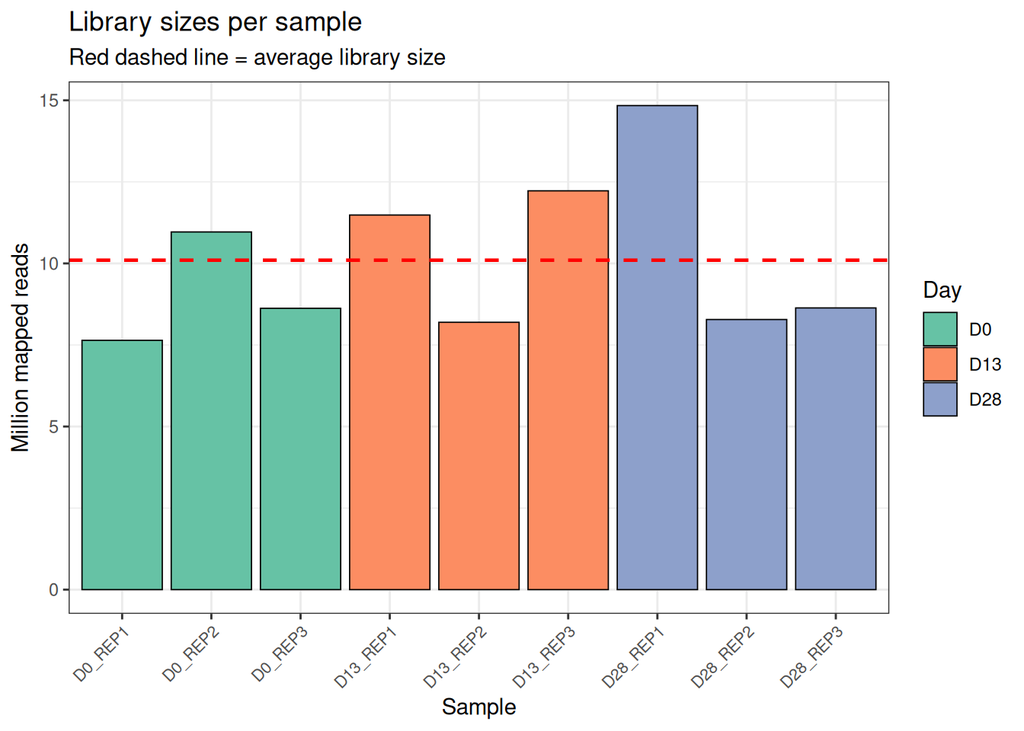

Library sizes per sample, ordered by differentiation day. Red dashed line = average library size. Bars should be roughly similar in height.

```r
# Build a data frame of library sizes, ordered by day for plotting
lib_sizes <- data.frame(
  sample    = colnames(dds),
  lib_size  = colSums(counts(dds)),
  day       = dds$day,
  cell_type = dds$cell_type
)

# Sort by day so the x-axis runs D0 → D13 → D28
lib_sizes <- lib_sizes[order(lib_sizes$day), ]
lib_sizes$sample <- factor(lib_sizes$sample, levels = lib_sizes$sample)

ggplot(lib_sizes, aes(x = sample, y = lib_size / 1e6, fill = day)) +
  geom_bar(stat = "identity", color = "black", linewidth = 0.3) +
  geom_hline(
    yintercept = mean(lib_sizes$lib_size) / 1e6,
    linetype   = "dashed", color = "red", linewidth = 0.8
  ) +
  scale_fill_brewer(
    palette = "Set2",
    breaks  = c("D0", "D13", "D28")
  ) +
  labs(
    title    = "Library sizes per sample",
    subtitle = "Red dashed line = average library size",
    x        = "Sample",
    y        = "Million mapped reads",
    fill     = "Day"
  ) +
  theme_bw() +
  theme(axis.text.x = element_text(angle = 45, hjust = 1, size = 8))
```

**How to interpret:** Bars should be roughly the same height (within 2× of each other). All bars should be above ~10 million reads. A dramatically shorter bar suggests that sample may have failed.

## 6.3 Count distributions

After VST normalization, the distribution of expression values should look similar across all samples. A violin plot shows both the shape of the distribution and the median (the horizontal line inside each box).

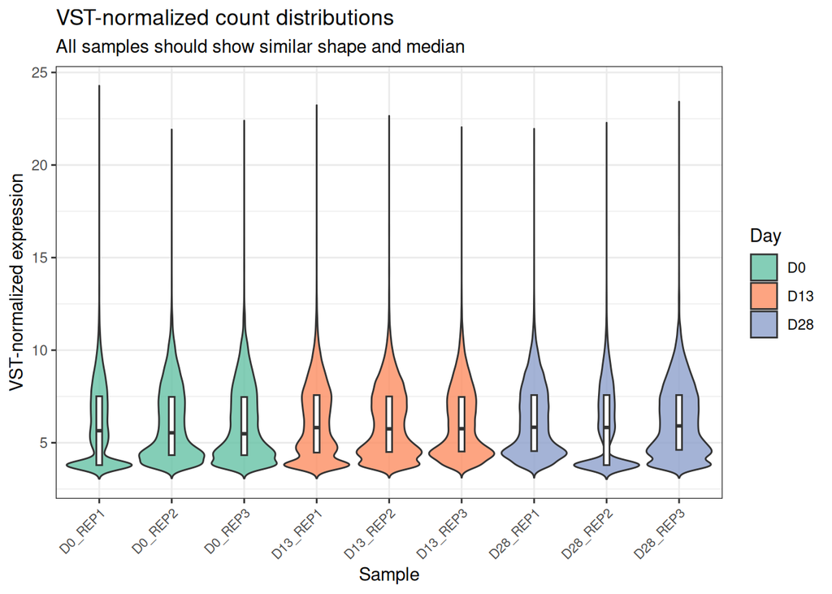

VST-normalized expression distributions per sample. All samples should show similar shape and median. Samples are ordered by differentiation day and colored accordingly.

```r
# Pre-compute the sample info table to avoid Bioconductor S4 dispatch
# conflicts when nesting inside dplyr pipes
sample_info <- as.data.frame(colData(dds))

# Reshape VST matrix to long format for ggplot
vsd_long <- assay(vsd) %>%
  as.data.frame() %>%
  rownames_to_column("gene") %>%
  pivot_longer(
    cols      = -gene,
    names_to  = "sample",
    values_to = "vst_count"
  ) %>%
  left_join(sample_info, by = "sample") %>%
  # Order samples by day (D0 → D13 → D28) for correct x-axis
  mutate(sample = factor(sample, levels = unique(sample[order(day)])))

ggplot(vsd_long, aes(x = sample, y = vst_count, fill = day)) +
  geom_violin(trim = FALSE, scale = "width", alpha = 0.8) +
  geom_boxplot(width = 0.08, fill = "white",
               outlier.shape = NA, coef = 0) +
  scale_fill_brewer(
    palette = "Set2",
    breaks  = c("D0", "D13", "D28")
  ) +
  labs(
    title    = "VST-normalized count distributions",
    subtitle = "All samples should show similar shape and median",
    x        = "Sample",
    y        = "VST-normalized expression",
    fill     = "Day"
  ) +
  theme_bw() +
  theme(axis.text.x = element_text(angle = 45, hjust = 1, size = 8))
```

**How to interpret:** All 9 violins should have a similar shape and median. If one sample’s distribution is dramatically compressed or shifted relative to its day-mates, it may warrant closer inspection in the PCA and distance heatmap.

## 6.4 PCA plot

Principal Component Analysis (PCA) compresses the expression of all ~15,000 genes into 2 dimensions so we can visualize sample relationships.

**PC1 (x-axis)** captures the largest source of variation in the data. **PC2 (y-axis)** captures the second largest. If the biology is working, PC1 should separate early (D0) from late (D28) timepoints — meaning the differentiation drove the biggest transcriptional change in the experiment.

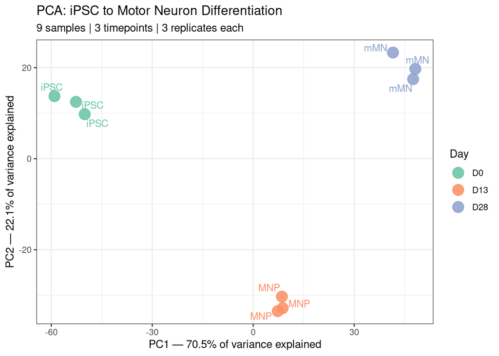

PCA of all 9 samples colored by differentiation day. Replicates of the same timepoint should cluster together. A clear trajectory from D0 to D28 along PC1 indicates that differentiation is the dominant source of variation.

```r
# Extract PCA coordinates from VST-normalized data
pca_data <- plotPCA(vsd, intgroup = c("day", "cell_type"), returnData = TRUE)

# Variance explained by each PC
pct_var <- round(100 * attr(pca_data, "percentVar"), 1)

ggplot(pca_data, aes(x = PC1, y = PC2, color = day, label = cell_type)) +
  geom_point(size = 5, alpha = 0.85) +
  geom_text_repel(
    size          = 3.5,
    show.legend   = FALSE,
    box.padding   = 0.3,
    point.padding = 0.3
  ) +
  scale_color_brewer(
    palette = "Set2",
    breaks  = c("D0", "D13", "D28")
  ) +
  labs(
    title    = "PCA: iPSC to Motor Neuron Differentiation",
    subtitle = "9 samples | 3 timepoints | 3 replicates each",
    x        = paste0("PC1 — ", pct_var[1], "% of variance explained"),
    y        = paste0("PC2 — ", pct_var[2], "% of variance explained"),
    color    = "Day"
  ) +
  theme_bw()
```

**How to interpret:**

- **Tight clusters** of same-day replicates = good reproducibility
- **Separation between days** = differentiation drove real transcriptomic changes
- **PC1 capturing the differentiation axis** is the ideal result — it means the biggest source of variation in the data is the biology, not a technical batch effect
- If replicates from the same day split apart, check the violin and library size plots for that sample

## 6.5 Sample-to-sample distance heatmap

The distance heatmap shows pairwise similarity between every pair of samples. We calculate Euclidean distance in gene expression space: **smaller distance = more similar expression**.

In the heatmap: **darker color = more similar**.

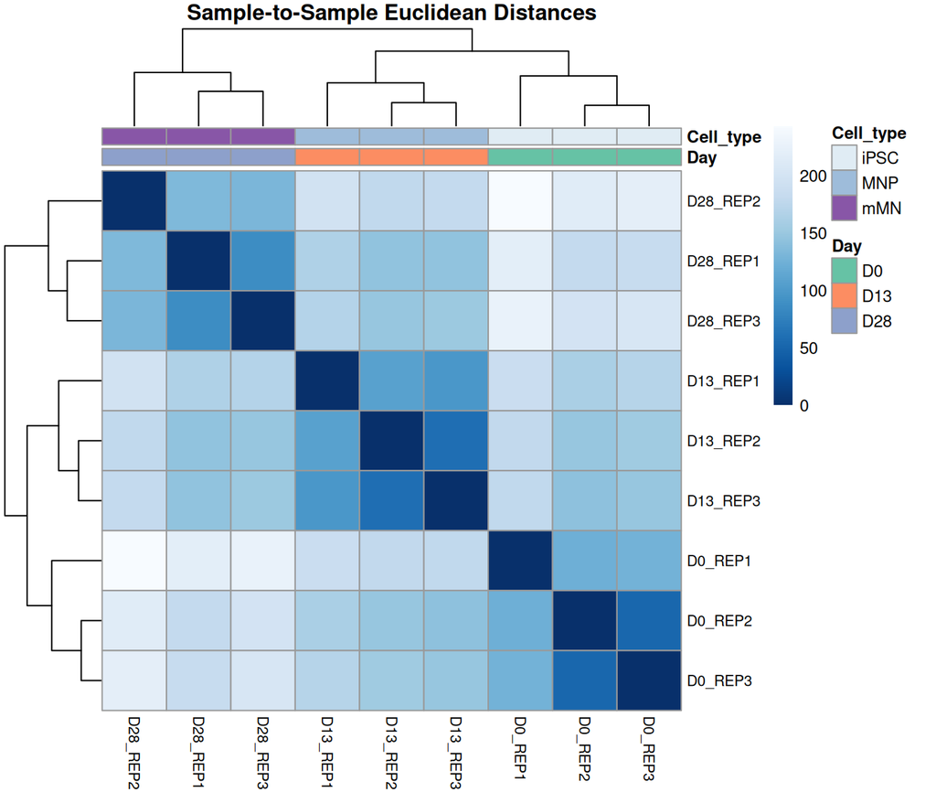

Sample-to-sample distance heatmap. Darker squares indicate more similar gene expression profiles. Replicates of the same timepoint should form dark blocks along the diagonal.

```r
# Euclidean distances between all pairs of samples
sample_dists <- dist(t(assay(vsd)))
dist_matrix  <- as.matrix(sample_dists)

# Annotation bar showing day and cell type
anno_col <- data.frame(
  Day       = metadata$day,
  Cell_type = metadata$cell_type,
  row.names = rownames(metadata)
)

# Shared annotation colors — defined once, reused in both heatmaps
# Day uses Set2 to match all ggplots in this tutorial
# Cell_type uses BuPu to visually distinguish it from Day
anno_colors <- list(
  Day = setNames(
    brewer.pal(3, "Set2"),
    c("D0", "D13", "D28")
  ),
  Cell_type = setNames(
    brewer.pal(3, "BuPu"),
    c("iPSC", "MNP", "mMN")
  )
)

# Color: dark blue = very similar, white = very different
heat_colors <- colorRampPalette(rev(brewer.pal(9, "Blues")))(255)

pheatmap(
  dist_matrix,
  clustering_distance_rows = sample_dists,
  clustering_distance_cols = sample_dists,
  annotation_col           = anno_col,
  annotation_colors        = anno_colors,
  col                      = heat_colors,
  main                     = "Sample-to-Sample Euclidean Distances",
  fontsize                 = 9,
  fontsize_row             = 8,
  fontsize_col             = 8
)
```

**How to interpret:**

- The diagonal is always darkest (each sample is identical to itself)
- Same-day replicates should cluster together in dark blocks
- D0 and D28 should be the most dissimilar (lightest color off-diagonal)
- An unexpected dark square between very different timepoints would suggest a mislabeled sample

# 7 Differential Expression Analysis with DESeq2

Now that QC looks good, we run the main analysis: finding genes that change significantly between conditions.

## 7.1 How DESeq2 works

DESeq2 uses a statistical model based on the **negative binomial distribution**, which is well-suited for RNA-seq count data (counts are non-negative integers with more variability than a simple Poisson model assumes).

The key steps DESeq2 performs automatically:

1. **Size factor estimation:** Corrects for differences in sequencing depth between samples
2. **Dispersion estimation:** Estimates how much each gene’s counts vary between replicates — more variable genes require stronger evidence to be called significant
3. **Model fitting:** Fits a generalized linear model to each gene, testing whether expression differs between groups
4. **Multiple testing correction:** Because we test ~15,000 genes simultaneously, we would expect hundreds of false positives by chance. DESeq2 uses the Benjamini-Hochberg method to control the False Discovery Rate (FDR)

```r
# Run the full DESeq2 pipeline (size factors → dispersion → model fitting)
# This may take 1–3 minutes for 9 samples
dds <- DESeq(dds)

cat("DESeq2 model fitting complete.\n\n")
```

```
## DESeq2 model fitting complete.
```

```r
cat("Available contrasts:\n")
```

```
## Available contrasts:
```

```r
print(resultsNames(dds))
```

```
## [1] "Intercept"     "day_D13_vs_D0" "day_D28_vs_D0"
```

## 7.2 Primary comparison: D28 (mature motor neurons) vs D0 (iPSCs)

We start with the most biologically meaningful comparison — mature motor neurons vs. the starting iPSC state. This gives us the complete transcriptional signature of motor neuron identity.

```r
# Extract results for D28 vs D0
# contrast = c("variable", "numerator", "denominator")
# Positive LFC = higher in D28; negative LFC = higher in D0
res_D28_D0 <- results(
  dds,
  contrast = c("day", "D28", "D0"),
  alpha    = 0.05
)

cat("── D28 (mMN) vs D0 (iPSC) ──────────────────────────────────\n")
```

```
## ── D28 (mMN) vs D0 (iPSC) ──────────────────────────────────
```

```r
summary(res_D28_D0)
```

```
##
## out of 23026 with nonzero total read count
## adjusted p-value < 0.05
## LFC > 0 (up)       : 3987, 17%
## LFC < 0 (down)     : 3245, 14%
## outliers [1]       : 60, 0.26%
## low counts [2]     : 4018, 17%
## (mean count < 3)
## [1] see 'cooksCutoff' argument of ?results
## [2] see 'independentFiltering' argument of ?results
```

**Understanding the results columns:**

| Column | Meaning |
| --- | --- |
| `baseMean` | Average normalized count across all 9 samples |
| `log2FoldChange` | log2(D28 / D0). Positive = higher in mMN; negative = higher in iPSC |
| `lfcSE` | Standard error of the log2FoldChange estimate |
| `pvalue` | Raw p-value — do NOT use this for significance |
| `padj` | Adjusted p-value (Benjamini-Hochberg FDR correction) — **use this** |

## 7.3 log2 fold change explained

Fold change measures how many times more (or less) a gene is expressed in one condition vs. another. We use the **log2** scale because it is symmetric:

- log2FC = +1 → 2× higher in D28 (2<sup>1</sup> = 2)
- log2FC = +2 → 4× higher in D28 (2<sup>2</sup> = 4)
- log2FC = −1 → 2× lower in D28 (2<sup>−1</sup> = 0.5)
- log2FC = 0 → no change

## 7.4 Why padj, not pvalue?

When testing 15,000 genes, we expect ~750 genes to have p < 0.05 purely by chance (5% of 15,000). The **adjusted p-value (padj)** corrects for this: padj < 0.05 means fewer than 5% of significant genes are expected to be false positives.

**Always use `padj` for significance decisions.**

## 7.5 LFC shrinkage

For lowly expressed genes, fold-change estimates are unreliable — a gene with 1 count in D0 and 2 counts in D28 technically shows a 2× fold change, but this is almost certainly noise.

`lfcShrink()` shrinks these unstable estimates toward zero, so only genes with consistent, strong fold changes stay prominent. This is recommended for volcano plots and ranked gene lists. In this dataset, shrinkage reduces the maximum |LFC| from 23.5 to 12.9 — the extreme values were driven by noisy low-count genes.

```r
# Apply LFC shrinkage using the 'ashr' adaptive shrinkage method
res_D28_D0_shrunk <- lfcShrink(
  dds,
  contrast = c("day", "D28", "D0"),
  type     = "ashr"
)

cat("LFC shrinkage applied.\n")
```

```
## LFC shrinkage applied.
```

```r
cat("  Before shrinkage — max |LFC|:",
    round(max(abs(res_D28_D0$log2FoldChange), na.rm = TRUE), 1), "\n")
```

```
##   Before shrinkage — max |LFC|: 23.5
```

```r
cat("  After shrinkage  — max |LFC|:",
    round(max(abs(res_D28_D0_shrunk$log2FoldChange), na.rm = TRUE), 1), "\n")
```

```
##   After shrinkage  — max |LFC|: 12.9
```

## 7.6 Significant DEGs

We apply two thresholds:

- **padj < 0.05**: statistically significant (< 5% FDR)
- **|log2FC| > 1**: biologically meaningful (≥ 2× change)

```r
# Define significance thresholds
# Adjust these if you want to be more or less stringent
PADJ_CUTOFF <- 0.05   # false discovery rate threshold
LFC_CUTOFF  <- 1      # minimum |log2 fold change| (= 2-fold change)

# Filter to significant DEGs
sig_genes <- res_D28_D0_shrunk %>%
  as.data.frame() %>%
  rownames_to_column("gene") %>%
  filter(!is.na(padj),
         padj < PADJ_CUTOFF,
         abs(log2FoldChange) > LFC_CUTOFF)

cat("── Significant DEGs ─────────────────────────────────────────\n")
```

```
## ── Significant DEGs ─────────────────────────────────────────
```

```r
cat("Total:         ", nrow(sig_genes), "\n")
```

```
## Total:          6305
```

```r
cat("Upregulated:   ", sum(sig_genes$log2FoldChange > 0),
    "(higher in mMN)\n")
```

```
## Upregulated:    3646 (higher in mMN)
```

```r
cat("Downregulated: ", sum(sig_genes$log2FoldChange < 0),
    "(higher in iPSC)\n\n")
```

```
## Downregulated:  2659 (higher in iPSC)
```

```r
cat("Top 10 most significant DEGs:\n")
```

```
## Top 10 most significant DEGs:
```

```r
sig_genes %>%
  arrange(padj) %>%
  select(gene, log2FoldChange, baseMean, padj) %>%
  mutate(
    log2FoldChange = round(log2FoldChange, 2),
    padj           = formatC(padj, format = "e", digits = 2)
  ) %>%
  head(10)
```

|  | gene | log2FoldChange | baseMean | padj |
| --- | --- | --- | --- | --- |
| 1 | MAP2 | 5.78 | 2999.9963 | 7.77e-130 |
| 2 | LIN28A | -8.29 | 4485.4293 | 6.92e-85 |
| 3 | ATP9A | 4.64 | 1374.8396 | 6.94e-81 |
| 4 | TRIM71 | -5.29 | 1594.9079 | 1.11e-79 |
| 5 | SYT4 | 8.96 | 2160.0617 | 3.76e-74 |
| 6 | RTN1 | 7.54 | 570.3337 | 2.62e-69 |
| 7 | NTRK3 | 5.84 | 689.4663 | 3.63e-69 |
| 8 | SNAP25 | 7.98 | 530.5941 | 6.99e-67 |
| 9 | ENSG00000294171 | 10.52 | 3677.0603 | 8.42e-65 |
| 10 | XKR4 | 5.92 | 467.7369 | 1.55e-64 |

**What the top genes tell us:**

The most significantly changed genes reflect the dramatic biology of this differentiation. Among the top 10 hits:

- **MAP2** (log2FC = +5.78, padj = 7.8e-130) — the single most statistically significant gene. MAP2 is a canonical marker of mature neurons and a major structural component of neuronal dendrites; its strong upregulation confirms successful neuronal differentiation.
- **SYT4** (log2FC = +8.96) and **SNAP25** (log2FC = +7.98) — core components of the synaptic vesicle fusion machinery. Their upregulation reflects the acquisition of synaptic identity in mature motor neurons.
- **RTN1** (log2FC = +7.54) and **NTRK3** (log2FC = +5.84) — RTN1 is a neuronal marker involved in axon shaping; NTRK3 (TrkC) is a neurotrophin receptor essential for motor neuron survival and axon outgrowth.
- **ATP9A** (log2FC = +4.64) — a phospholipid flippase involved in membrane asymmetry, increasingly linked to neuronal vesicle trafficking.
- **LIN28A** (log2FC = −8.29, padj = 6.9e-85) — the most significantly downregulated gene. LIN28A is an RNA-binding protein that actively maintains the pluripotent state; its rapid silencing is a hallmark of the exit from pluripotency.
- **TRIM71** (log2FC = −5.29) — also known as LIN41, TRIM71 is a direct target of LIN28A and helps suppress differentiation genes in stem cells. Its co-downregulation with LIN28A reflects coordinated dismantling of the pluripotency network.

Note that **STMN2** (Stathmin-2, ALS-relevant axon regeneration gene) does not appear in the top 10 by adjusted p-value but shows among the highest fold changes in the full results (log2FC ≈ +11–12). With only 3 replicates per group, the statistical ranking favors genes with consistent expression across all samples; highly variable or lowly expressed genes can have large fold changes but wider confidence intervals.

## 7.7 Save results

```r
# Save the full results table (all tested genes)
write.csv(
  as.data.frame(res_D28_D0_shrunk) %>% rownames_to_column("gene"),
  file      = file.path(out_dir, "DESeq2_D28_vs_D0_all_genes.csv"),
  row.names = FALSE
)

# Save only the significant DEGs
write.csv(
  sig_genes %>% arrange(padj),
  file      = file.path(out_dir, "DESeq2_D28_vs_D0_significant_DEGs.csv"),
  row.names = FALSE
)

cat("Results saved to:", out_dir, "\n")
```

```
## Results saved to: /cluster/tufts/workshop/public/2026summer/iyerlab/part2/results
```

```r
cat("  DESeq2_D28_vs_D0_all_genes.csv         —",
    nrow(res_D28_D0_shrunk), "genes\n")
```

```
##   DESeq2_D28_vs_D0_all_genes.csv         — 23026 genes
```

```r
cat("  DESeq2_D28_vs_D0_significant_DEGs.csv  —",
    nrow(sig_genes), "DEGs\n")
```

```
##   DESeq2_D28_vs_D0_significant_DEGs.csv  — 6305 DEGs
```

# 8 Visualization

## 8.1 Volcano plot

A volcano plot shows every tested gene as a single point:

- **X-axis:** log2 fold change — how much the gene changed
- **Y-axis:** −log10(padj) — how significant the change is (higher = more significant)

The shape resembles a volcano: a dense mass of unchanged genes in the center, with significant genes “erupting” on the flanks.

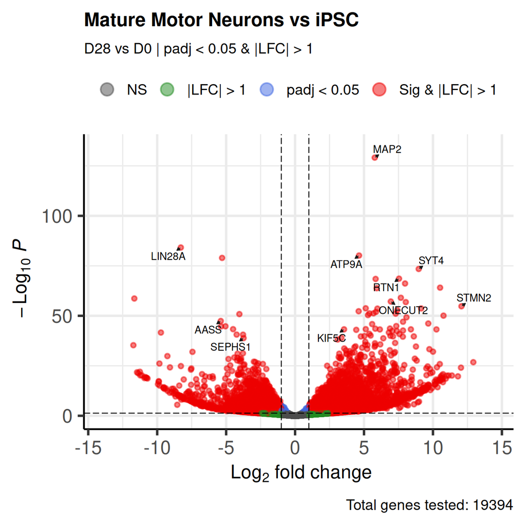

Volcano plot: D28 mature motor neurons vs D0 iPSC. Red points meet both significance thresholds (padj < 0.05 and |LFC| > 1). Key motor neuron markers (top right) and pluripotency markers (top left) are labeled.

```r
# Genes to highlight — known markers relevant to this differentiation
genes_to_label <- c(
  "STMN2",   # top DEG; axon regeneration; ALS-relevant
  "MAP2",    # canonical mature neuron marker
  "RTN1",
  "AASS",
  "ONECUT2",
  "SEPHS1",
  "LIN28A",  # top DEG; RNA-binding protein that maintains pluripotency
  "ATP9A",
  "SYT4",
  "KIF5C"
)

EnhancedVolcano(
  res_D28_D0_shrunk,
  lab             = rownames(res_D28_D0_shrunk),
  x               = "log2FoldChange",
  y               = "padj",
  selectLab       = genes_to_label,
  title           = "Mature Motor Neurons vs iPSC",
  subtitle        = paste0("D28 vs D0 | padj < ", PADJ_CUTOFF,
                           " & |LFC| > ", LFC_CUTOFF),
  pCutoff         = PADJ_CUTOFF,
  FCcutoff        = LFC_CUTOFF,
  pointSize       = 1.5,
  labSize         = 3.5,
  drawConnectors  = TRUE,
  widthConnectors = 0.4,
  colAlpha        = 0.5,
  legendLabels    = c("NS", "|LFC| > 1", "padj < 0.05", "Sig & |LFC| > 1"),
  caption         = paste0("Total genes tested: ",
                           sum(!is.na(res_D28_D0_shrunk$padj)))
)
```

**How to interpret:**

- **Top right:** genes strongly and significantly upregulated in mature motor neurons. STMN2 and MAP2 are among the highest, reflecting axon growth and neuronal maturation.
- **Top left:** genes strongly downregulated — LIN28A is the most dramatically silenced, reflecting loss of pluripotency.
- **Bottom center:** genes that do not change meaningfully — most genes in any experiment fall here.

## 8.2 MA plot

An MA plot displays every tested gene as a single point using two coordinates:

- **X-axis (A — average):** mean normalized expression across all samples (log10 scale) — how highly expressed the gene is overall
- **Y-axis (M — minus):** log2 fold change — how much the gene changed between conditions

The name “MA” comes from these two axes: **M**inus (log ratio) and **A**verage.

### 8.2.1 Why the MA plot matters

The MA plot answers a question the volcano plot cannot: **does fold change depend on expression level?** In raw (unshrunk) results, lowly expressed genes routinely show extreme fold changes simply because their counts are noisy — a gene with 2 counts in D0 and 4 counts in D28 is technically 2-fold changed, but this is almost certainly sampling noise, not biology. On the MA plot this artifact appears as a wide “fan” of points on the left side (low expression), where fold-change estimates spread far from zero even though most of those genes are not truly differentially expressed.

LFC shrinkage corrects this: it down-weights fold-change estimates for genes with low counts or high variability, pulling them back toward zero. Plotting before and after shrinkage side-by-side is one of the clearest ways to see that shrinkage worked — the fan should collapse into a tight band around y = 0.

This is why we always apply `lfcShrink()` before making volcano plots or ranked gene lists: the fold changes become trustworthy representations of the underlying biology rather than statistical noise.

### 8.2.2 What to look for

- **Horizontal band around y = 0:** most genes do not change, so the bulk of points should lie near the x-axis across the full expression range
- **Fan shape on the left (before shrinkage):** low-expression genes have inflated, unreliable fold-change estimates
- **Collapsed fan after shrinkage:** those noisy estimates have been pulled toward zero — the plot should look much more symmetric
- **Blue points (significant DEGs):** genes that pass the padj threshold; they should appear across a range of expression levels, not only among the most highly expressed genes

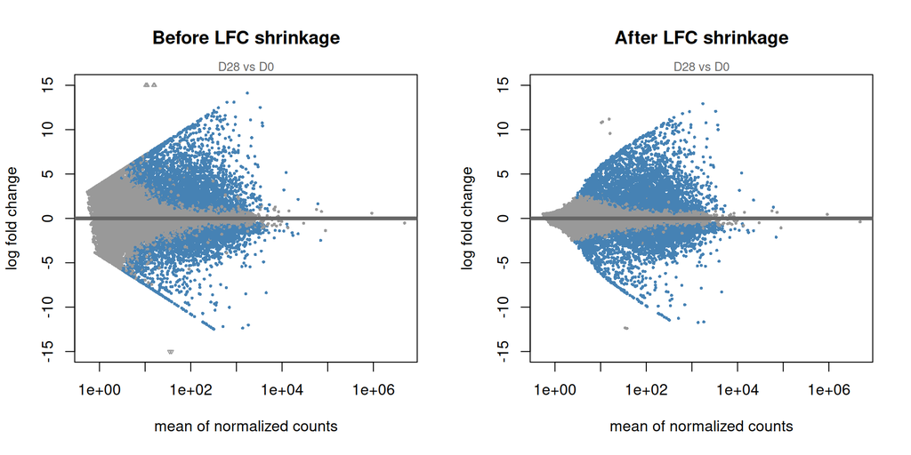

MA plot: D28 vs D0. Each point is one gene. Blue = significant (padj < 0.05). Left: raw LFC estimates show a fan of extreme fold changes at low expression. Right: after LFC shrinkage, noisy estimates collapse toward zero.

```r
# Side-by-side comparison: raw vs shrunk LFC
# plotMA() is DESeq2's built-in base-R MA plot function
par(mfrow = c(1, 2))

plotMA(
  res_D28_D0,
  main   = "Before LFC shrinkage",
  ylim   = c(-15, 15),
  alpha  = 0.05,
  colSig = "steelblue"
)
abline(h = 0, col = "grey40", lty = 2)
mtext("D28 vs D0", side = 3, line = 0, cex = 0.8, col = "grey40")

plotMA(
  res_D28_D0_shrunk,
  main   = "After LFC shrinkage",
  ylim   = c(-15, 15),
  alpha  = 0.05,
  colSig = "steelblue"
)
abline(h = 0, col = "grey40", lty = 2)
mtext("D28 vs D0", side = 3, line = 0, cex = 0.8, col = "grey40")
```

```r
par(mfrow = c(1, 1))
```

## 8.3 Heatmap of top DEGs

The heatmap lets us visualize expression patterns of the most significant genes across all 9 samples simultaneously. We **z-score** each gene (subtract its mean, divide by its standard deviation) to show relative patterns rather than absolute counts. A z-score of +2 means a gene is 2 standard deviations above its average across all samples.

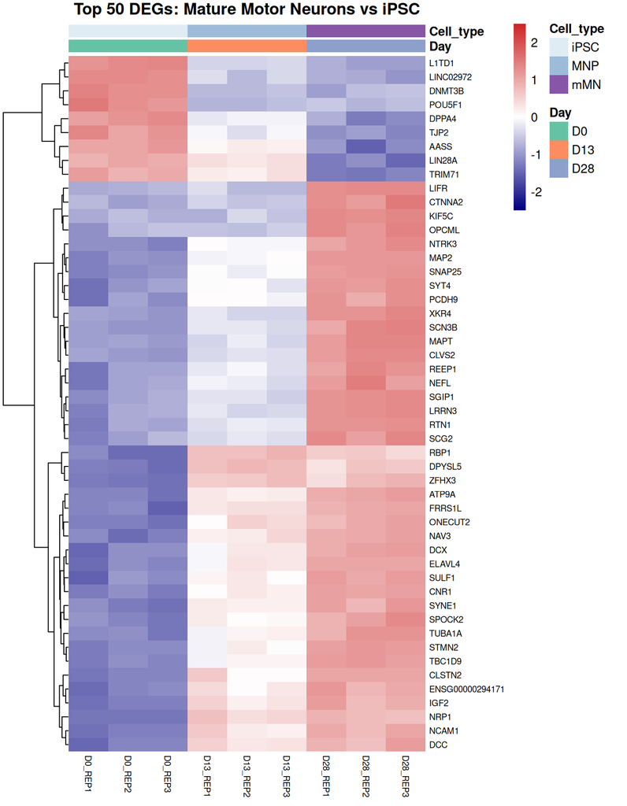

Heatmap of the top 50 most significant DEGs. Expression is z-scored per gene. Columns are ordered D0 → D28. Red = relatively high expression; blue = relatively low. Row clustering groups genes by co-expression pattern.

```r
# Number of top genes to display — increase for more detail, decrease for clarity
N_TOP_GENES <- 50

# Select the top N most significant DEGs
top_genes <- sig_genes %>%
  arrange(padj) %>%
  slice_head(n = N_TOP_GENES) %>%
  pull(gene)

# Extract VST-normalized expression for these genes
mat <- assay(vsd)[top_genes, ]

# Z-score each gene (row) so we see relative patterns across samples
mat_scaled <- t(scale(t(mat)))

# Clip extreme values to prevent outliers from dominating the color scale
mat_scaled[mat_scaled >  2.5] <-  2.5
mat_scaled[mat_scaled < -2.5] <- -2.5

# Reorder columns by day (D0 → D13 → D28)
# metadata$day is already a factor with the correct level order,
# so order() on it gives us the right column sequence
col_order  <- order(metadata$day)
mat_scaled <- mat_scaled[, col_order]

# Column annotation bars (day and cell type shown above the heatmap)
# Must be reordered to match the column order of mat_scaled
anno_col <- data.frame(
  Day       = metadata$day[col_order],
  Cell_type = metadata$cell_type[col_order],
  row.names = rownames(metadata)[col_order]
)

pheatmap(
  mat_scaled,
  annotation_col    = anno_col,
  annotation_colors = anno_colors,
  show_rownames     = TRUE,
  show_colnames     = TRUE,
  fontsize_row      = 7,
  fontsize_col      = 7,
  cluster_cols      = FALSE,  # keep D0 → D28 column order
  cluster_rows      = TRUE,   # cluster genes by expression pattern
  color             = colorRampPalette(c("navy", "white", "firebrick3"))(100),
  main              = paste0("Top ", N_TOP_GENES,
                             " DEGs: Mature Motor Neurons vs iPSC"),
  breaks            = seq(-2.5, 2.5, length.out = 101),
  border_color      = NA
)
```

**How to interpret:**

- **Red blocks on the right (D28):** motor neuron genes switching on in mature neurons
- **Blue blocks on the right:** pluripotency genes (high in D0) being silenced
- **Row clustering** groups genes that share similar trajectories — you should see a clear cluster of D0-high genes and a separate cluster of D28-high genes
- The visual contrast between the left (D0) and right (D28) columns should be striking, reflecting the magnitude of this differentiation

## 8.4 Marker gene expression across differentiation

Before trusting statistical results, we visually verify key marker genes. If known markers behave as expected, we can be confident in the rest of the analysis.

We plot **size-factor normalized counts** (DESeq2’s depth-corrected counts) on a log10 scale.

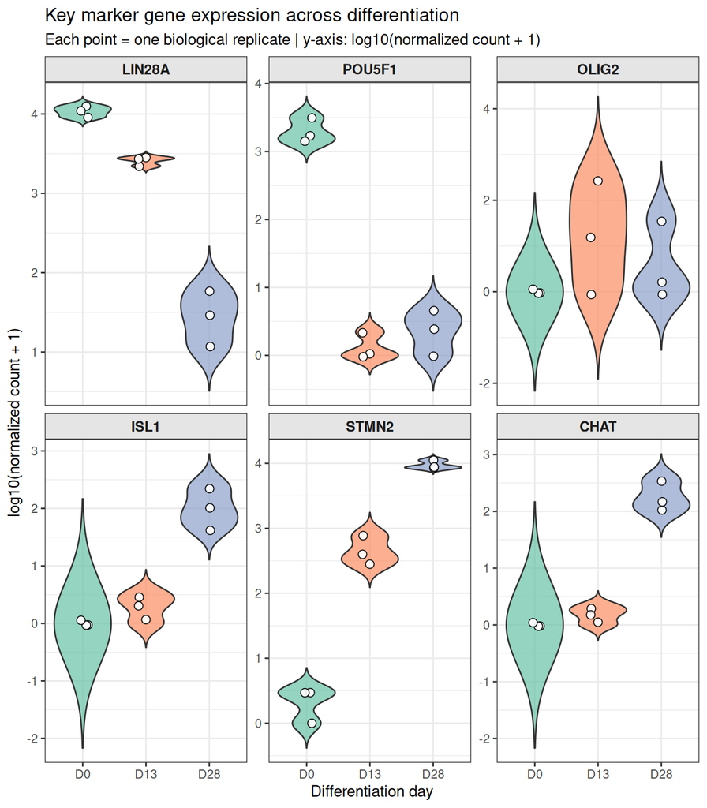

```r
# Marker genes to visualize — covers pluripotency, progenitor, and mature neuron stages
marker_genes <- c(
  "LIN28A",  # pluripotency RNA-binding protein — drops sharply after D0
  "POU5F1",  # OCT4 — master pluripotency factor, drops at D0
  "OLIG2",   # motor neuron progenitor marker — expected to peak at D13
  "ISL1",    # pan-motor neuron marker — rises from D13 onward
  "STMN2",   # top upregulated DEG; axon marker; ALS-relevant
  "CHAT",    # cholinergic marker — late expression (may be low in vitro)
  "HOXC9"    # thoracic/lumbar axial identity marker
)

# Extract normalized counts and filter to markers present in the data
norm_counts  <- counts(dds, normalized = TRUE)
marker_genes_present <- marker_genes[marker_genes %in% rownames(norm_counts)]

# Pre-compute sample info to avoid S4 dispatch issues in dplyr pipes
sample_info2 <- as.data.frame(colData(dds))

# Reshape to long format
marker_df <- norm_counts[marker_genes_present, ] %>%
  as.data.frame() %>%
  rownames_to_column("gene") %>%
  pivot_longer(
    cols      = -gene,
    names_to  = "sample",
    values_to = "norm_count"
  ) %>%
  left_join(sample_info2, by = "sample") %>%
  mutate(gene = factor(gene, levels = marker_genes_present))

ggplot(marker_df, aes(x = day, y = log10(norm_count + 1), fill = day)) +
  geom_violin(trim = FALSE, alpha = 0.7, scale = "width") +
  geom_jitter(
    width  = 0.12, size = 2.5,
    color  = "black", alpha = 0.9,
    shape  = 21, fill = "white"
  ) +
  facet_wrap(~ gene, scales = "free_y", ncol = 3) +
  scale_fill_brewer(
    palette = "Set2",
    breaks  = c("D0", "D13", "D28")
  ) +
  labs(
    title    = "Key marker gene expression across differentiation",
    subtitle = "Each point = one biological replicate | y-axis: log10(normalized count + 1)",
    x        = "Differentiation day",
    y        = "log10(normalized count + 1)",
    fill     = "Day"
  ) +
  theme_bw() +
  theme(
    legend.position  = "none",
    strip.text       = element_text(face = "bold", size = 10),
    strip.background = element_rect(fill = "grey90")
  )
```

**What to look for:**

# 9 Functional Enrichment Analysis

We now know *which* genes change. The next question is: *what do these genes do?* Enrichment analysis connects gene lists to annotated biological processes.

## 9.1 Gene Ontology (GO) enrichment

**Gene Ontology (GO)** is a structured vocabulary that describes gene function in three categories:

- **Biological Process (BP):** What the gene does in the cell (e.g., “axonogenesis”, “neurotransmitter secretion”)
- **Molecular Function (MF):** The biochemical activity (e.g., “acetylcholine receptor binding”)
- **Cellular Component (CC):** Where in the cell (e.g., “neuromuscular junction”, “axon terminal”)

We focus on **Biological Process** because it answers the most biologically relevant question: what processes are activated in mature motor neurons?

GO enrichment tests: is the fraction of our upregulated genes in a given GO term *higher* than expected by chance? The result is an adjusted p-value for each term.

**Note:** Gene symbols (e.g., “ISL1”) must be converted to Entrez IDs before running enrichment. A small number of genes will not map (usually novel genes or non-coding RNAs).

```r
# Genes upregulated in mature motor neurons
up_genes <- sig_genes %>%
  filter(log2FoldChange > 0) %>%
  pull(gene)

cat("Upregulated DEGs used for enrichment:", length(up_genes), "\n")
```

```
## Upregulated DEGs used for enrichment: 3646
```

```r
# Convert gene symbols to Entrez IDs
gene_ids <- bitr(
  up_genes,
  fromType = "SYMBOL",
  toType   = "ENTREZID",
  OrgDb    = org.Hs.eg.db
)
cat("Mapped to Entrez IDs:", nrow(gene_ids), "\n")
```

```
## Mapped to Entrez IDs: 3299
```

```r
cat("Could not map:       ", length(up_genes) - nrow(gene_ids),
    "(typically novel genes or ncRNAs)\n\n")
```

```
## Could not map:        347 (typically novel genes or ncRNAs)
```

```r
# GO Biological Process enrichment
go_res <- enrichGO(
  gene          = gene_ids$ENTREZID,
  OrgDb         = org.Hs.eg.db,
  ont           = "BP",
  pAdjustMethod = "BH",
  qvalueCutoff  = 0.05,
  readable      = TRUE   # show gene symbols instead of Entrez IDs
)

cat("Significant GO terms:", nrow(as.data.frame(go_res)), "\n")
```

```
## Significant GO terms: 767
```

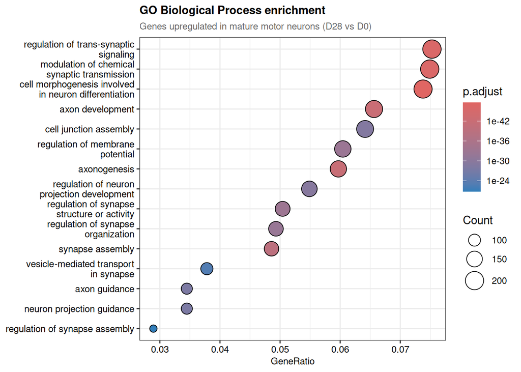

```r
dotplot(go_res, showCategory = 15, font.size = 9) +
  labs(
    title    = "GO Biological Process enrichment",
    subtitle = "Genes upregulated in mature motor neurons (D28 vs D0)"
  ) +
  theme(
    plot.title    = element_text(face = "bold", size = 11),
    plot.subtitle = element_text(size = 9, color = "grey40")
  )
```

**How to read the dotplot:**

A term can have a large dot (many genes) but lighter color (modest significance) if the GO term is very broad. Conversely, a small dot with dark color means few genes hit the term but they are very specifically enriched. The most informative hits are both large and dark.

**What the results show:**

## 9.2 KEGG pathway enrichment

**KEGG** is a database of hand-curated biological pathways — biochemical reactions, signaling cascades, and disease pathways. Unlike GO (which is broad), KEGG pathways are specific and highly curated.

```r
kegg_res <- enrichKEGG(
  gene         = gene_ids$ENTREZID,
  organism     = "hsa",   # Homo sapiens
  pvalueCutoff = 0.05
)

cat("Significant KEGG pathways:", nrow(as.data.frame(kegg_res)), "\n")
```

```
## Significant KEGG pathways: 79
```

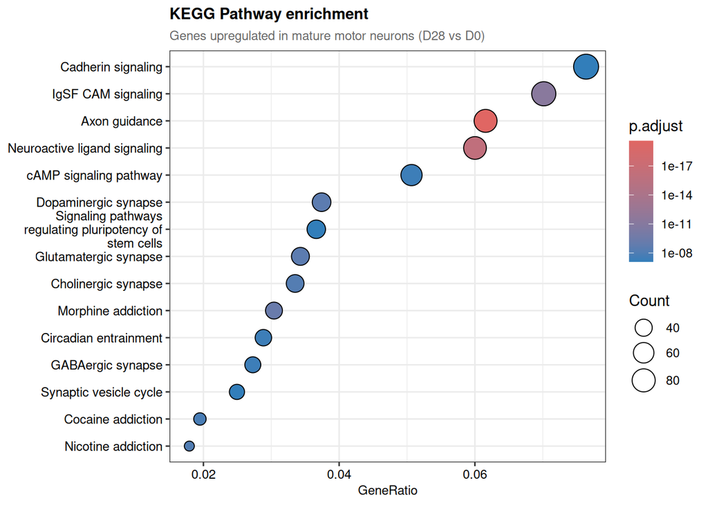

Dotplot of the top 15 enriched KEGG pathways in genes upregulated in mature motor neurons.

```r
dotplot(kegg_res, showCategory = 15, font.size = 9) +
  labs(
    title    = "KEGG Pathway enrichment",
    subtitle = "Genes upregulated in mature motor neurons (D28 vs D0)"
  ) +
  theme(
    plot.title    = element_text(face = "bold", size = 11),
    plot.subtitle = element_text(size = 9, color = "grey40")
  )
```

**What the results show:**

## 9.3 Save enrichment results

```r
write.csv(
  as.data.frame(go_res),
  file      = file.path(out_dir, "GO_BP_enrichment_mMN_upregulated.csv"),
  row.names = FALSE
)
write.csv(
  as.data.frame(kegg_res),
  file      = file.path(out_dir, "KEGG_enrichment_mMN_upregulated.csv"),
  row.names = FALSE
)
cat("Enrichment results saved to:", out_dir, "\n")
```

```
## Enrichment results saved to: /cluster/tufts/workshop/public/2026summer/iyerlab/part2/results
```

# 10 Step-by-Step Differentiation Comparisons

The D28 vs D0 comparison gives us the complete motor neuron signature, but it does not tell us *when* each gene turns on or off. To understand the regulatory logic of differentiation step-by-step, we run pairwise comparisons between each consecutive pair of timepoints.

| Comparison | Biology |
| --- | --- |
| D13 vs D0 | iPSC → MNP: neural commitment and progenitor specification |
| D28 vs D13 | MNP → mMN: birth and maturation of motor neurons |

```r
# Both consecutive pairwise comparisons
comparisons <- list(
  "D13_vs_D0"  = c("day", "D13", "D0"),
  "D28_vs_D13" = c("day", "D28", "D13")
)

# For each comparison: run DESeq2 with LFC shrinkage, count DEGs
step_summary <- lapply(names(comparisons), function(name) {
  res_shrunk <- lfcShrink(dds, contrast = comparisons[[name]], type = "ashr")
  sig <- res_shrunk %>%
    as.data.frame() %>%
    filter(!is.na(padj),
           padj < PADJ_CUTOFF,
           abs(log2FoldChange) > LFC_CUTOFF)
  data.frame(
    Comparison = name,
    Total_DEGs = nrow(sig),
    Up         = sum(sig$log2FoldChange > 0),
    Down       = sum(sig$log2FoldChange < 0)
  )
})

step_df <- do.call(rbind, step_summary)

cat("── DEGs at each differentiation step ───────────────────────\n")
```

```
## ── DEGs at each differentiation step ───────────────────────
```

```r
print(step_df)
```

```
##   Comparison Total_DEGs   Up Down
## 1  D13_vs_D0       3276 1994 1282
## 2 D28_vs_D13       3420 1982 1438
```

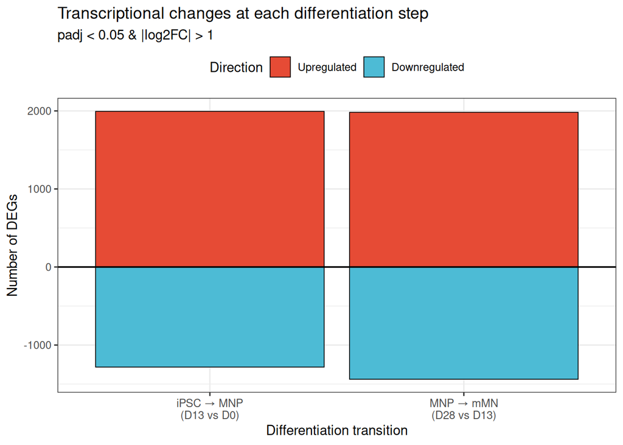

Number of significant DEGs at each consecutive differentiation step. Red = upregulated; blue = downregulated. Steps with more DEGs represent larger transcriptional transitions.

```r
# Reshape for a diverging bar plot
step_df_long <- step_df %>%
  pivot_longer(
    cols      = c("Up", "Down"),
    names_to  = "Direction",
    values_to = "Count"
  ) %>%
  mutate(
    # Downregulated genes plotted below the x-axis
    Count      = ifelse(Direction == "Down", -Count, Count),
    Direction  = factor(Direction, levels = c("Up", "Down")),
    Comparison = factor(Comparison,
                        levels = c("D13_vs_D0", "D28_vs_D13"))
  )

ggplot(step_df_long, aes(x = Comparison, y = Count, fill = Direction)) +
  geom_bar(stat = "identity", color = "black", linewidth = 0.3) +
  geom_hline(yintercept = 0, color = "black", linewidth = 0.6) +
  scale_fill_manual(
    values = c("Up" = "#E64B35", "Down" = "#4DBBD5"),
    labels = c("Up" = "Upregulated", "Down" = "Downregulated")
  ) +
  scale_x_discrete(
    labels = c(
      "D13_vs_D0"  = "iPSC → MNP\n(D13 vs D0)",
      "D28_vs_D13" = "MNP → mMN\n(D28 vs D13)"
    )
  ) +
  labs(
    title    = "Transcriptional changes at each differentiation step",
    subtitle = paste0("padj < ", PADJ_CUTOFF, " & |log2FC| > ", LFC_CUTOFF),
    x        = "Differentiation transition",
    y        = "Number of DEGs",
    fill     = "Direction"
  ) +
  theme_bw() +
  theme(
    legend.position = "top",
    axis.text.x     = element_text(size = 9)
  )
```

**How to interpret:** Each bar represents one differentiation transition. More DEGs = a larger transcriptional remodeling event at that step.

In this dataset, the two transitions are strikingly similar in magnitude: **D13 vs D0 yields 3,276 DEGs** (1,994 up, 1,282 down) and **D28 vs D13 yields 3,420 DEGs** (1,982 up, 1,438 down). The iPSC → MNP transition reflects the shutdown of the pluripotency program and activation of neural progenitor identity. The MNP → mMN transition is slightly larger, capturing the extensive gene expression remodeling as progenitors exit the cell cycle, acquire neuronal morphology, and build their synaptic and axonal machinery. The near-equal scale of the two transitions underscores that motor neuron maturation is as transcriptionally demanding as the initial commitment to neural fate.

# 11 Summary and Next Steps

## 11.2 Common questions

**Q: What if I get very few significant DEGs?** Try relaxing thresholds (`PADJ_CUTOFF <- 0.1` or `LFC_CUTOFF <- 0.5`). Also check PCA — if replicates cluster poorly, high variability is reducing statistical power.

**Q: Why do some genes have padj = NA?** DESeq2 sets padj = NA for genes where counts are too low to test reliably (independent filtering). This is normal and expected.

**Q: Can I find genes that change across any timepoint (not just one pair)?** Yes — use the Likelihood Ratio Test: `DESeq(dds, test = "LRT", reduced = ~ 1)`. This identifies genes with any significant variation across the time course.

**Q: How do I compare a different pair of timepoints?** Change the contrast in `lfcShrink()`: `contrast = c("day", "D13", "D0")` compares D13 to D0, and so on.

*This tutorial was prepared for the Iyer Lab RNA-seq Training, Tufts University. Dataset: Solomon et al. 2021, BMC Molecular and Cell Biology, BioProject PRJNA638768. For questions, contact the Shirley Li, Bioinformatician, Research Technology, Tufts University, xue.li37@tufts.edu*